# Homework 2

Ahmet Tabakoglu

07/05/2021

# Time Series Regression and Forecasting

In this project, “Consumer Price Index for Alcoholic Beverages and Tobacco” data between January 2014 - March 2021 is gathered from [EVDS](https://evds2.tcmb.gov.tr/) website. The aim is to build a forecasting model and predict the data for April 2021 using time series regression.

### Converting the Data into Time Series Data

The data is imported and converted into time series data.

```r
library(ggplot2)
library(data.table)
library("readxl")
cpiData=read_excel("C:\\Users\\AHMET\\Desktop\\EVDS1.xlsx")
cpiData=ts(cpiData, frequency = 12, start = c(2014,1))
cpiData
```

```
##         Jan    Feb    Mar    Apr    May    Jun    Jul    Aug    Sep    Oct
## 2014 412.55 412.65 412.57 412.67 412.05 411.81 420.02 418.09 413.42 413.41
## 2015 430.69 428.79 428.76 428.83 428.86 428.83 433.80 435.34 436.87 436.83
## 2016 478.81 483.58 483.59 483.88 483.73 483.72 517.80 535.59 535.63 535.60
## 2017 588.45 588.60 588.59 588.65 588.66 588.70 591.00 591.27 591.32 591.32
## 2018 593.67 593.86 593.87 593.92 594.83 594.96 599.46 602.00 602.41 603.51
## 2019 609.26 609.94 609.99 651.31 709.14 709.43 714.76 851.35 866.61 866.63
## 2020 866.45 854.81 855.12 855.31 860.99 868.44 870.40 872.12 872.47 872.40
## 2021 878.17 879.35 879.67
##         Nov    Dec
## 2014 413.42 413.37
## 2015 436.85 436.87
## 2016 535.64 574.89
## 2017 591.40 591.36
## 2018 604.56 605.52
## 2019 866.66 866.65
## 2020 872.43 872.31
## 2021
```

The graph of monthly CPI values is plotted below.

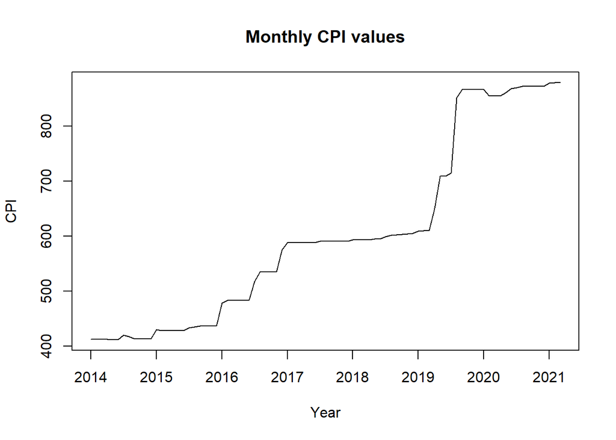

```r
plot(cpiData, xlab="Year", ylab="CPI", main="Monthly CPI values")
```

As a first impression, it can be stated that the data has an increasing trend since the CPI value increases most of the time as the time goes by. Secondly, seasonality is not observed because behavior of the data is not similar during the years. For example, during 2017, CPI value barely increases whereas it extremely increases during 2019.

To satisfy the constant variance assumption of residuals, it is more logical to work with logarithms of the CPI values to reduce the numerical size of variance. The graph of log(CPI) values versus time is plotted below.

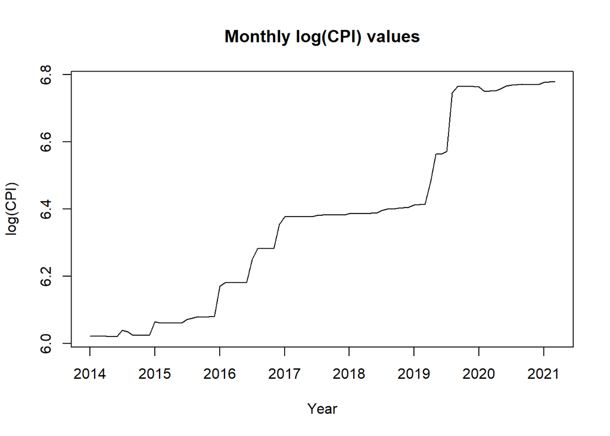

```r
cpi_log=log(cpiData)
plot(cpi_log, xlab="Year", ylab="log(CPI)", main="Monthly log(CPI) values")
```

### Constructing the Data Table

As mentioned before, log(CPI) values will be used in data table to ensure the assumptions of residuals. Hence, the data table starts being constructed by addition of log(CPI) values into the first column. Later on, since the data has an increasing trend, it is reasonable to add trend data to second column of the data table. In order to test the effect of seasonality, month information is added to third column. After these operations, current state of the data table can be seen below.

```r
cpindex=data.table(log_cpindex=as.numeric(cpi_log))
cpindex[,trend:=1:.N]
month=seq(1,12,by=1)
cpindex=cbind(cpindex,month)
cpindex
```

```
##     log_cpindex trend month
##  1:    6.022357     1     1
##  2:    6.022600     2     2
##  3:    6.022406     3     3
##  4:    6.022648     4     4
##  5:    6.021145     5     5
##  6:    6.020562     6     6
##  7:    6.040302     7     7
##  8:    6.035697     8     8
##  9:    6.024464     9     9
## 10:    6.024440    10    10
## 11:    6.024464    11    11
## 12:    6.024343    12    12
## 13:    6.065389    13     1
## 14:    6.060967    14     2
```

[output cut: 74 more lines]

### Interpretation of the Autocorrelation Function

The graph of autocorrelation function of the time series data is plotted below.

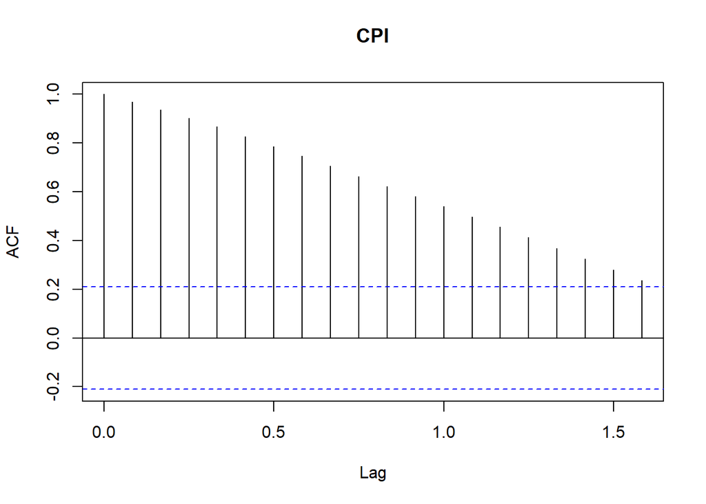

```r
acf(cpiData)
```

It is observed that there is a high autocorrelation between consecutive months. Therefore, the log(CPI) data with lag = 1 can be useful for the model fitting.

### Model Fitting

While the model is being constructed, components of the data table are added to the model and checked first whether they make a better model. Initially, it is better to start with trend component since there is an increasing trend observed.

```r
library(forecast)
fit=lm(log_cpindex~trend, data = cpindex)
summary(fit)
```

```
##
## Call:
## lm(formula = log_cpindex ~ trend, data = cpindex)
##
## Residuals:
##       Min        1Q    Median        3Q       Max
## -0.147390 -0.041369 -0.003062  0.047198  0.142736
##
## Coefficients:
##              Estimate Std. Error t value Pr(>|t|)
## (Intercept) 5.9201122  0.0141957   417.0   <2e-16 ***
## trend       0.0101702  0.0002802    36.3   <2e-16 ***
## ---
## Signif. codes:  0 '***' 0.001 '**' 0.01 '*' 0.05 '.' 0.1 ' ' 1
##
## Residual standard error: 0.06563 on 85 degrees of freedom
## Multiple R-squared:  0.9394, Adjusted R-squared:  0.9387
## F-statistic:  1317 on 1 and 85 DF,  p-value: < 2.2e-16
```

Checking residuals of the current model:

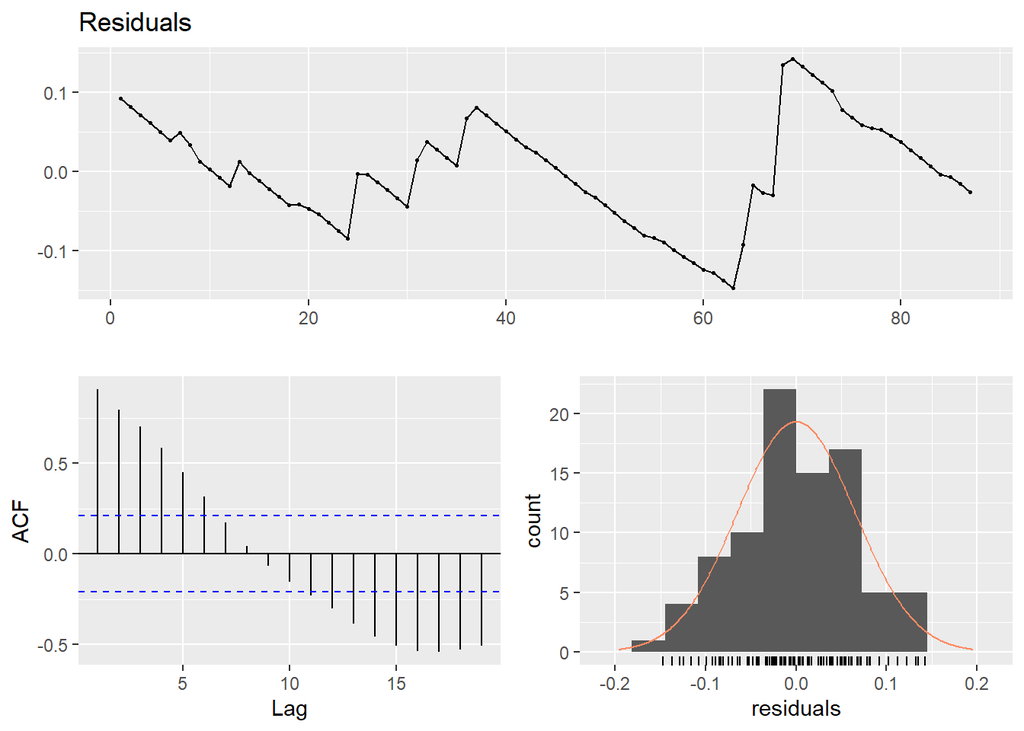

```
##
##  Breusch-Godfrey test for serial correlation of order up to 10
##
## data:  Residuals
## LM test = 73.765, df = 10, p-value = 8.272e-12
```

```r
checkresiduals(fit)
```

As seen above, the zero mean assumption of residuals is not really satisfied. Also, there is a high autocorrelation between residuals. For these reasons, the model should be improved.

Next, we add month data to the model to see whether the model improves.

```r
fit=lm(log_cpindex~trend+month, data = cpindex)
summary(fit)
```

```
##
## Call:
## lm(formula = log_cpindex ~ trend + month, data = cpindex)
##
## Residuals:
##       Min        1Q    Median        3Q       Max
## -0.150559 -0.041114 -0.002283  0.047278  0.144963
##
## Coefficients:
##               Estimate Std. Error t value Pr(>|t|)
## (Intercept)  5.9255471  0.0187388 316.218   <2e-16 ***
## trend        0.0101774  0.0002820  36.091   <2e-16 ***
## month       -0.0009065  0.0020272  -0.447    0.656
## ---
## Signif. codes:  0 '***' 0.001 '**' 0.01 '*' 0.05 '.' 0.1 ' ' 1
##
## Residual standard error: 0.06595 on 84 degrees of freedom
## Multiple R-squared:  0.9395, Adjusted R-squared:  0.9381
## F-statistic: 652.6 on 2 and 84 DF,  p-value: < 2.2e-16
```

Recall that seasonality is not observed in the monthly CPI values graph. If there was seasonality, it would be expected to see improvement in the model with the addition of the month data. However, as expected, there is no improvement in the model since residual standard error increases and adjusted R-squared value decreases. Therefore, there is no need to add month data to the model.

```r
library(useful)
cpiwithlag=shift.column(data=cpindex, columns="log_cpindex", newNames = sprintf("lag1"), len=1)
cpiwithlag
```

```
##     log_cpindex trend month     lag1
##  1:    6.022357     1     1 6.022600
##  2:    6.022600     2     2 6.022406
##  3:    6.022406     3     3 6.022648
##  4:    6.022648     4     4 6.021145
##  5:    6.021145     5     5 6.020562
##  6:    6.020562     6     6 6.040302
##  7:    6.040302     7     7 6.035697
##  8:    6.035697     8     8 6.024464
##  9:    6.024464     9     9 6.024440
## 10:    6.024440    10    10 6.024464
## 11:    6.024464    11    11 6.024343
## 12:    6.024343    12    12 6.065389
## 13:    6.065389    13     1 6.060967
## 14:    6.060967    14     2 6.060897
```

[output cut: 73 more lines]

Then, lag1 data is included in the model.

```r
fit=lm(log_cpindex~trend+lag1, data = cpiwithlag)
summary(fit)
```

```
##
## Call:
## lm(formula = log_cpindex ~ trend + lag1, data = cpiwithlag)
##
## Residuals:
##       Min        1Q    Median        3Q       Max
## -0.155342  0.000522  0.006381  0.011178  0.029355
##
## Coefficients:
##              Estimate Std. Error t value Pr(>|t|)
## (Intercept) 0.4098226  0.2590329   1.582    0.117
## trend       0.0006649  0.0004619   1.440    0.154
## lag1        0.9297586  0.0437013  21.275   <2e-16 ***
## ---
## Signif. codes:  0 '***' 0.001 '**' 0.01 '*' 0.05 '.' 0.1 ' ' 1
##
## Residual standard error: 0.02612 on 83 degrees of freedom
## Multiple R-squared:  0.9904, Adjusted R-squared:  0.9901
## F-statistic:  4260 on 2 and 83 DF,  p-value: < 2.2e-16
```

As expected, there is a significant improvement in the model since residual standard error decreases and adjusted R-squared increases. For further investigation, residuals information of the new model should be checked.

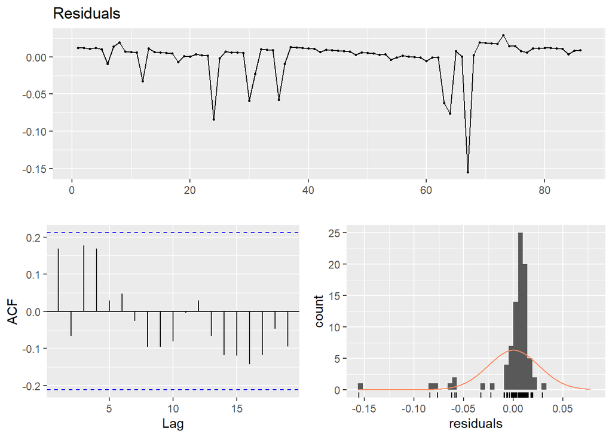

```
##
##  Breusch-Godfrey test for serial correlation of order up to 10
##
## data:  Residuals
## LM test = 10.659, df = 10, p-value = 0.3847
```

```r
checkresiduals(fit)
```

Compared to the first model, the zero mean assumption is almost satisfied except some downward peaks, and autocorrelation pretty much decreased. Moreover, adjusted R-squared value is closer to 1 and residual standard error is closer to 0 when compared to the first model. Therefore, the current model can be used for forecasting.

Adding fitted values and residuals of the current model into the data table:

```r
cpiwithlag[,fitted:=fitted(fit)]
cpiwithlag[,residual:=residuals(fit)]
cpiwithlag
```

```
##     log_cpindex trend month     lag1   fitted      residual
##  1:    6.022357     1     1 6.022600 6.010051  0.0123061738
##  2:    6.022600     2     2 6.022406 6.010536  0.0120638844
##  3:    6.022406     3     3 6.022648 6.011426  0.0109797426
##  4:    6.022648     4     4 6.021145 6.010693  0.0119551026
##  5:    6.021145     5     5 6.020562 6.010816  0.0103283371
##  6:    6.020562     6     6 6.040302 6.029835 -0.0092728774
##  7:    6.040302     7     7 6.035697 6.026218  0.0140845544
##  8:    6.035697     8     8 6.024464 6.016439  0.0192577162
##  9:    6.024464     9     9 6.024440 6.017081  0.0073825873
## 10:    6.024440    10    10 6.024464 6.017769  0.0066709851
## 11:    6.024464    11    11 6.024343 6.018321  0.0061427042
## 12:    6.024343    12    12 6.065389 6.057149 -0.0328055722
## 13:    6.065389    13     1 6.060967 6.053703  0.0116857300
## 14:    6.060967    14     2 6.060897 6.054303  0.0066645733
```

[output cut: 73 more lines]

The graph of actual versus fitted data is plotted below to see how accurate the final model is.

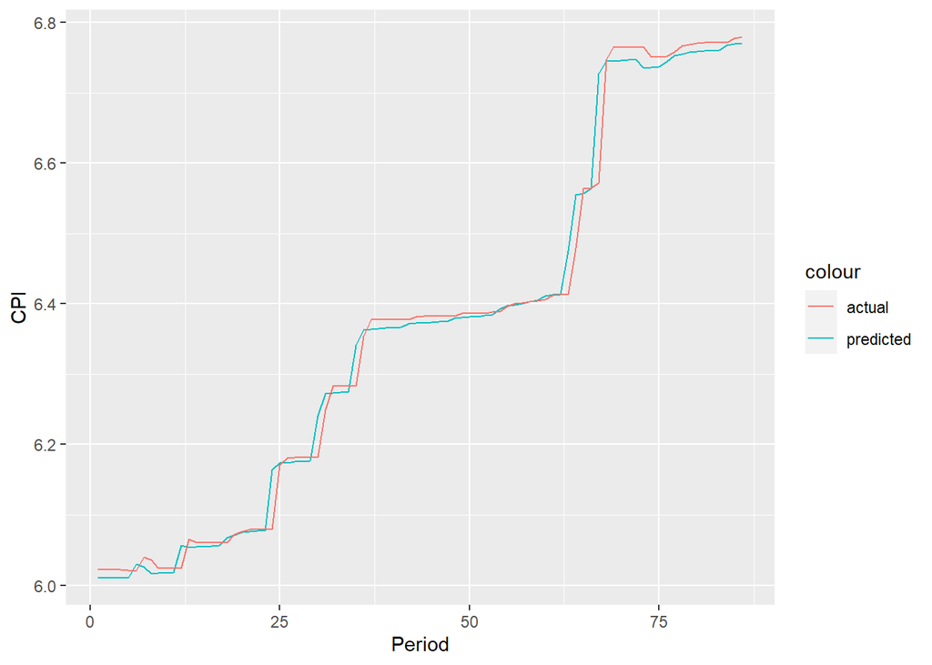

```r
ggplot() +
  geom_line(data = cpiwithlag, aes(x = trend, y = fitted,color = "predicted")) +
  geom_line(data = cpiwithlag, aes(x = trend, y = log_cpindex,color = "actual")) +
  xlab('Period') +
  ylab('CPI')
```

### Forecasting

In the first data table, there were 87 data points including March 2021 data. However, when the lag1 data is added, the amount of data points decreased to 86. Hence, 2 period ahead forecasting is needed to predict the 88th period, which is April 2021. To predict the log(CPI) values, the formula below will be used.

Predicted log(CPI) = (intercept estimate) + (period number) x (trend estimate) + (lag1 estimate) x (lag1 value of the base period)

The prediction is going to be made by using 86th period as the base period.

```r
prediction88 = 0.4098226 + 88 * 0.0006649 + 6.779547 * 0.9297586
prediction88
```

```
## [1] 6.771676
```

Predicted log(CPI) value for April 2021 = 6.771676

### Conclusion

In order to forecast the future values using an unregulated data set, it is primarily important to manipulate the data properly. In this project, the gathered data set was converted to time series data first. Then, the values were reduced to their logarithms to use the data more effectively. Afterwards, the data table was constructed and all useful additional data was added to the table. After all these operations, the data set became more proper to build a prediction model. The final prediction model was constructed after checking all properties that might improve the model. Finally, the forecast for the requested period was made using the constructed model. To sum up, forecasting using time series regression became more proper with correct data manipulation.